# 3.3 Other Considerations in the Regression Model

## 3.3.1 Qualitative Predictors

선형 회귀 모형에서 모든 변수가 꼭 정량적(quantitative) 변수일 필요는 없다. 정성적(qualitative)한 변수일 수도 있다.

ex) 남자 / 여자, 한국인 / 중국인 / 일본인

Credit 데이터를 사용하여 정성적 변수의 활용을 살펴보자.

```r
getwd()
```

"C:/Users/fbi.SNU/Downloads"

```r
# Credit 데이터는 ISLR 패키지에 없다. 홈페이지에서 다운로드 받아서 R의 working directory 에 넣은 다음 읽도록 하자.
credit <- read.csv('Credit.csv', header=T)
```

## Qualitative predictors with Only Two Levels

정성적 변수의 수준이 두 종류일 경우에 회귀 분석에 사용하는 방법을 다룬다.

출처: http://www.ats.ucla.edu/stat/r/library/contrast_coding.htm

```r
?contr.treatment
```

### 1) Contrast coding

### contr.treatment 함수의 base = 1인 경우에, 첫 번째 수준을 0, 두 번째 수준을 1로 코딩한다.

### base 는 기본 값이 1이다.

```r
contr.treatment(2)
```

|  | 2 |
| --- | --- |
| 1 | 0 |
| 2 | 1 |

```r
contrasts(credit$Gender) = contr.treatment(2)
```

```r
summary(lm(Balance~Gender, credit))
```

```
Call:
lm(formula = Balance ~ Gender, data = credit)

Residuals:
    Min      1Q  Median      3Q     Max
-529.54 -455.35  -60.17  334.71 1489.20

Coefficients:
            Estimate Std. Error t value Pr(>|t|)
(Intercept)   509.80      33.13  15.389   <2e-16 ***
Gender2        19.73      46.05   0.429    0.669
---
Signif. codes:  0 '***' 0.001 '**' 0.01 '*' 0.05 '.' 0.1 ' ' 1

Residual standard error: 460.2 on 398 degrees of freedom
Multiple R-squared:  0.0004611,	Adjusted R-squared:  -0.00205
F-statistic: 0.1836 on 1 and 398 DF,  p-value: 0.6685
```

Gender2는 Gender 항목의 두 번째 수준을 이야기 하는 것이다. 그래서 남성일 경우에는 Balance의 평균 추정치가 ${$509.80}$이고, 여성의 경우에는 ${$19.73}$이 증가한 ${$529.53}$ 인 것을 알 수 있다. 그러나 Gender2의 estimate의 p-value가 유의 수준 0.05보다 크기 때문에 사실상 성별에 따른 Balance의 차이가 존재한다는 주장에는 아무런 통계적 근거가 없다.

### base = 2인 경우에, 두 번째 수준을 0으로 코딩한다.

```r
contrasts(credit$Gender) = contr.treatment(2, base=2)
```

```r
summary(lm(Balance~Gender, credit))
```

```
Call:
lm(formula = Balance ~ Gender, data = credit)

Residuals:
    Min      1Q  Median      3Q     Max
-529.54 -455.35  -60.17  334.71 1489.20

Coefficients:
            Estimate Std. Error t value Pr(>|t|)
(Intercept)   529.54      31.99  16.554   <2e-16 ***
Gender1       -19.73      46.05  -0.429    0.669
---
Signif. codes:  0 '***' 0.001 '**' 0.01 '*' 0.05 '.' 0.1 ' ' 1

Residual standard error: 460.2 on 398 degrees of freedom
Multiple R-squared:  0.0004611,	Adjusted R-squared:  -0.00205
F-statistic: 0.1836 on 1 and 398 DF,  p-value: 0.6685
```

### 2) Deviation coding

### 기본적으로 contr.sum 함수는 첫 번째 수준부터 -1로 설정한다. 여기서는 책의 예시를 따라 두 번째 수준을 1로, 첫 번째 수준을 -1로 설정한다.

```r
contrasts(credit$Gender) = contr.sum(2)[c(2,1),]
```

```r
summary(lm(Balance~Gender, credit))
```

```
Call:
lm(formula = Balance ~ Gender, data = credit)

Residuals:
    Min      1Q  Median      3Q     Max
-529.54 -455.35  -60.17  334.71 1489.20

Coefficients:
            Estimate Std. Error t value Pr(>|t|)
(Intercept)  519.670     23.026  22.569   <2e-16 ***
Gender1        9.867     23.026   0.429    0.669
---
Signif. codes:  0 '***' 0.001 '**' 0.01 '*' 0.05 '.' 0.1 ' ' 1

Residual standard error: 460.2 on 398 degrees of freedom
Multiple R-squared:  0.0004611,	Adjusted R-squared:  -0.00205
F-statistic: 0.1836 on 1 and 398 DF,  p-value: 0.6685
```

## Qualitative Predictors with More than Two Levels

정성적 변수의 수준이 세 종류 이상일 경우에 회귀 분석에 어떻게 사용되는지 살펴보자.

```r
contrasts(credit$Ethnicity) <- contr.treatment(3)
```

```r
summary(lm(Balance~Ethnicity, credit))
```

```
Call:
lm(formula = Balance ~ Ethnicity, data = credit)

Residuals:
    Min      1Q  Median      3Q     Max
-531.00 -457.08  -63.25  339.25 1480.50

Coefficients:
            Estimate Std. Error t value Pr(>|t|)
(Intercept)   531.00      46.32  11.464   <2e-16 ***
Ethnicity2    -18.69      65.02  -0.287    0.774
Ethnicity3    -12.50      56.68  -0.221    0.826
---
Signif. codes:  0 '***' 0.001 '**' 0.01 '*' 0.05 '.' 0.1 ' ' 1

Residual standard error: 460.9 on 397 degrees of freedom
Multiple R-squared:  0.0002188,	Adjusted R-squared:  -0.004818
F-statistic: 0.04344 on 2 and 397 DF,  p-value: 0.9575
```

기준으로 삼는 ethnicity는 African American 이고, Ethnicity 2, 3는 각각 Asian 과 Caucasian 이다. 역시나 p-value 들을 살펴 보았을 때 인종에 따른 Balance 추정치 평균이 다르다고 주장할 수 없다.

결정 계수들(Correlation Coefficients)과 p-value 들은 dummy variable coding의 방식에 따라 그 값이 달라진다. 그렇기 때문에 개별 결정계수들에 의존하는 것보다 F-test를 활용할 수 있다.

위의 경우, F 통계량의 p-value 가 0.9575 이기 때문에 영가설을 기각할 수 없다. 다시말해 인종이 Balance 추정치를 계산하는 데 영향을 끼친다고 주장할 수 없다.

## When incorporating both qualitative and quantitative predictors

```r
summary(credit)
```

[output not shown]

```r
contrasts(credit$Student) <- contr.treatment(2)
```

```r
summary(lm(Balance~Income+Student, credit))
```

```
Call:
lm(formula = Balance ~ Income + Student, data = credit)

Residuals:
    Min      1Q  Median      3Q     Max
-762.37 -331.38  -45.04  323.60  818.28

Coefficients:
            Estimate Std. Error t value Pr(>|t|)
(Intercept) 211.1430    32.4572   6.505 2.34e-10 ***
Income        5.9843     0.5566  10.751  < 2e-16 ***
Student2    382.6705    65.3108   5.859 9.78e-09 ***
---
Signif. codes:  0 '***' 0.001 '**' 0.01 '*' 0.05 '.' 0.1 ' ' 1

Residual standard error: 391.8 on 397 degrees of freedom
Multiple R-squared:  0.2775,	Adjusted R-squared:  0.2738
F-statistic: 76.22 on 2 and 397 DF,  p-value: < 2.2e-16
```

```r
summary(lm(Balance~Income*Student, credit))
```

```
Call:
lm(formula = Balance ~ Income * Student, data = credit)

Residuals:
    Min      1Q  Median      3Q     Max
-773.39 -325.70  -41.13  321.65  814.04

Coefficients:
                Estimate Std. Error t value Pr(>|t|)
(Intercept)     200.6232    33.6984   5.953 5.79e-09 ***
Income            6.2182     0.5921  10.502  < 2e-16 ***
Student2        476.6758   104.3512   4.568 6.59e-06 ***
Income:Student2  -1.9992     1.7313  -1.155    0.249
---
Signif. codes:  0 '***' 0.001 '**' 0.01 '*' 0.05 '.' 0.1 ' ' 1

Residual standard error: 391.6 on 396 degrees of freedom
Multiple R-squared:  0.2799,	Adjusted R-squared:  0.2744
F-statistic:  51.3 on 3 and 396 DF,  p-value: < 2.2e-16
```

## 3.3.2 Extensions of the Linear Model

일반적인 회귀 모형 ($Y$ = ${\beta_0}$ + ${\beta_1}$$X_1$ + $\beta_2$$X_2$ + ... + $\beta_p$$X_p$ + $\epsilon$)은 해석이 용이한 결과들을 제공하고, 실생활의 문제들을 해결하는 데도 유용하다.

그러나 이 모형은 두 가지 제한적인 가정을 지니고 있으며, 종종 이 가정들이 위반되고는 한다.

예측 변수(predictor)와 결과(response)의 관계는

1. 가법적(additive)
2. 선형적(linear)

하다는 것이 두 가정이다.

Additive = the effect of changes in a predictor $X_j$ on the response Y is independent of the values of the other predictors.

Linear = the change in the response Y due to a one-unit change in $X_j$ is constant, regardless of the value of $X_j$

### Removing the Additive Aassumption

TV와 라디오가 모두 판매에 영향을 미치는 것으로 판단.

회귀 모형의 가정은, 예를 들어 TV 광고를 하는 수준을 1만큼 올렸을 때, 이것은 현재 라디오 광고가 판매에 끼치는 영향과는 독립적으로 판매에 영향을 미친다는 것

그러나 만일 라디오 광고에 투자하는 비용을 증가시켰을 때 TV 광고의 효과를 증가시킨다고 한다면? -> 라디오 광고에 투자하는 비용이 증가하면 TV의 결정계수(기울기)가 커져야 한다.

#### Synergy effect / interaction effect

TV 광고에 대부분 투자하거나, 라디오 광고에 대부분 투자하는 것 보다 TV 광고와 라디오 광고에 비용을 적절히 분배하여 투자하는 경우 판매량이 훨씬 늘어난다고 할 때 synergy effect / interaction effect 가 존재한다고 한다.

```r
advertising <- read.csv('Advertising.csv', header=T)
```

```r
summary(lm(Sales~TV+Radio, advertising))
```

```
Call:
lm(formula = Sales ~ TV + Radio, data = advertising)

Residuals:
    Min      1Q  Median      3Q     Max
-8.7977 -0.8752  0.2422  1.1708  2.8328

Coefficients:
            Estimate Std. Error t value Pr(>|t|)
(Intercept)  2.92110    0.29449   9.919   <2e-16 ***
TV           0.04575    0.00139  32.909   <2e-16 ***
Radio        0.18799    0.00804  23.382   <2e-16 ***
---
Signif. codes:  0 '***' 0.001 '**' 0.01 '*' 0.05 '.' 0.1 ' ' 1

Residual standard error: 1.681 on 197 degrees of freedom
Multiple R-squared:  0.8972,	Adjusted R-squared:  0.8962
F-statistic: 859.6 on 2 and 197 DF,  p-value: < 2.2e-16
```

다음의 선형 회귀 모형을 보자.

$Y$ = ${\beta_0}$ + ${\beta_1}$$X_1$ + $\beta_2$$X_2$ + ... + $\beta_p$$X_p$ + $\epsilon$

$X_1$의 수준이 변하는 것은 $X_2$의 존재에 아무런 영향을 받지 않는다. 다시 말해, $X_2$가 존재하지 않더라도 $X_1$의 수준이 1 증가할 경우 Y는 $\beta_1$ 유닛의 평균만큼 증가할 것이다. 이는 interaction effect를 나타내지 못한다.

이 때의 해결 방법은 $X_1$과 $X_2$를 곱한 변수를 새로 모형에 추가하는 것이다.

```r
summary(lm(Sales~TV*Radio, advertising))
```

```
Call:
lm(formula = Sales ~ TV * Radio, data = advertising)

Residuals:
    Min      1Q  Median      3Q     Max
-6.3366 -0.4028  0.1831  0.5948  1.5246

Coefficients:
             Estimate Std. Error t value Pr(>|t|)
(Intercept) 6.750e+00  2.479e-01  27.233   <2e-16 ***
TV          1.910e-02  1.504e-03  12.699   <2e-16 ***
Radio       2.886e-02  8.905e-03   3.241   0.0014 **
TV:Radio    1.086e-03  5.242e-05  20.727   <2e-16 ***
---
Signif. codes:  0 '***' 0.001 '**' 0.01 '*' 0.05 '.' 0.1 ' ' 1

Residual standard error: 0.9435 on 196 degrees of freedom
Multiple R-squared:  0.9678,	Adjusted R-squared:  0.9673
F-statistic:  1963 on 3 and 196 DF,  p-value: < 2.2e-16
```

위의 모형과 비교했을 때 TV:Radio의 변수가 하나 추가 되었다. 이 설명 변수는 TV와 라디오의 상호작용 효과를 의미한다. 설명변수의 p-value가 매우 낮은 것은 통계적으로 유의미함을 나타낸다.

아래의 식에서 확인할 수 있듯이 라디오 광고에 투자하는 비용의 수준이 증가하는 것은 곧 TV 광고 효과의 수준에 직접적인 영향을 끼친다.

$Sales$ = ${\beta_0}$ + ${\beta_1}$x$TV$ + $\beta_2$x$Radio$ + $\beta_3$x$(Radio x TV)$ + $\epsilon$ $=$ ${\beta_0}$ + (${\beta_1}$+$\beta_3$x$Radio$) x $TV$ + $\beta_2$x$Radio$ + $\epsilon$

### hierarchical principle

상호작용 효과를 모형에 포함하면, 주 효과 역시 p-value가 크더라도 모형에 포함해야 한다.

-> $X_1X_2$가 효과가 있다면, $X_1$ 이나 $X_2$가 0인지 아닌지는 관심의 대상이 아니며, 대부분의 경우 상호작용 효과를 나타내는 변수들은 주 효과를 표현하는 변수들과 연관되어 있다.

이제 credit 데이터에서 Balance 를 정량적 변수인 수입(Income)과 정성적 변수인 학생 여부(Student)로 추정해 보자.

상호작용 변수를 넣지 않은 상태에서는 책에 나온 대로 식이

$\beta_0$ + $\beta_1$ x $income_i$ + $\beta_2$ : i 번째 사람이 학생일 경우

$\beta_0$ + $\beta_1$ x $income_i$ + $0$ : i 번째 사람이 학생이 아닐 경우

위와 같이 된다. 각 beta 값들은 위에 구했던 회귀 모형의 결과를 참고하도록 한다.

```r
credit
```

```r
is.student <- rep(0, nrow(credit))
```

```r
is.student[credit$Student == "Yes"] = 1
```

```r
credit$is.student <- is.student
```

```r
credit$balance.est <- 211.1430+5.9843*credit$Income + 382.6705*credit$is.student
```

```r
sub1 <- data.frame(credit$X, credit$Income, credit$balance.est, credit$is.student)
```

```r
colnames(sub1) <- c("X", "income", "balance.est", "is.student")
```

```r
sub1$is.student <- as.factor(sub1$is.student)
```

```r
library(ggplot2)
```

```r
options(jupyter.plot_mimetypes = 'image/png')
```

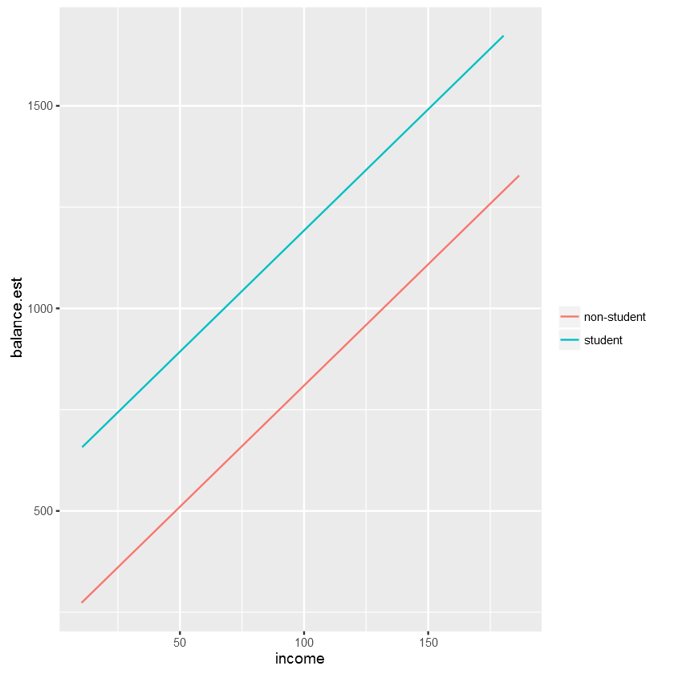

```r
ggplot(sub1, aes(x=income, y=balance.est, colour=is.student))+geom_line()+scale_colour_discrete(breaks = c(0,1), name = "", labels = c("non-student", "student"))
```

수입의 변화가 학생인지 아닌지에 따라서 balance 의 추정치에 미치는 영향이 있을 수도 있는데, 위와 같이 보면 집단별 구분은 존재하지 않는다 (기울기가 동일).

상호작용 변수를 집어 넣어서 분석해보도록 하자.

```r
credit$balance.est2 <- (200.6232+476.6758*credit$is.student)+(6.2182-1.9992*credit$is.student)*credit$Income
```

```r
sub2 <- data.frame(credit$X, credit$Income, credit$balance.est2, credit$is.student)
```

```r
colnames(sub2) <- c("X", "income", "balance.est2", "is.student")
```

```r
sub2$is.student <- as.factor(is.student)
```

```r
options(jupyter.plot_mimetypes = 'image/png')
```

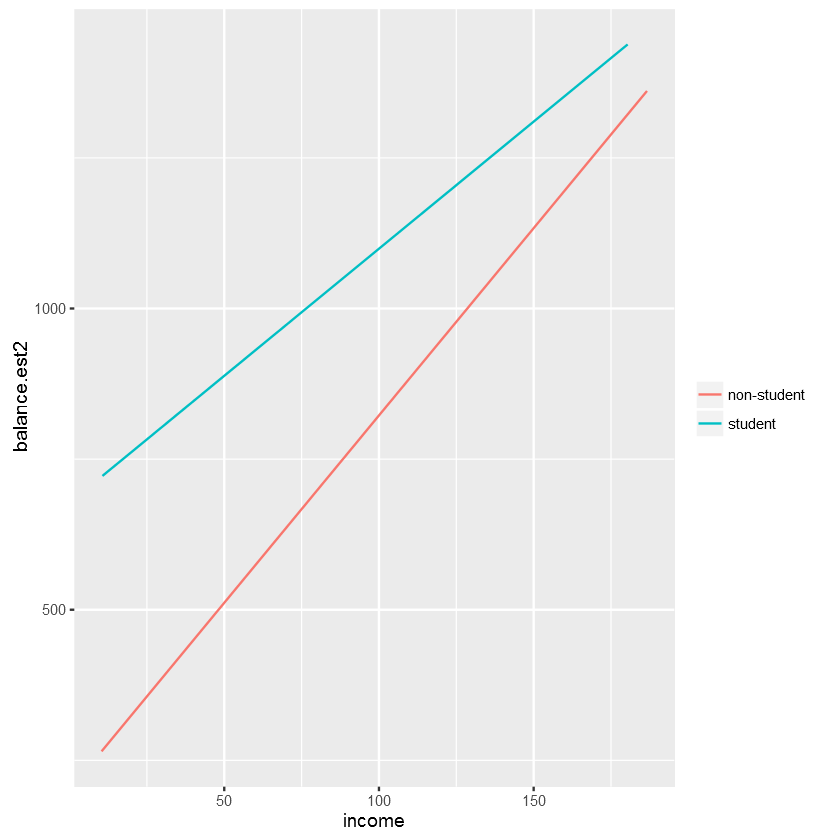

```r
ggplot(sub2, aes(x=income, y=balance.est2, colour=is.student))+geom_line()+scale_colour_discrete(name = " ", breaks = c(0,1), labels = c("non-student", "student"))
```

학생일 경우 기울기가 덜 가파른 것을 볼 수 있다. 이는 학생일 경우에 소득의 증가가 있더라도 신용 카드의 balance가 상대적으로 덜 변하고, 학생이 아닐 경우에는 소득의 증가가 있을 경우 신용 카드의 balance가 더 큰 폭으로 변한다는 것을 알 수 있다.

그러나 이전의 회귀 모형 분석에서 소득과 학생 신분 여부의 상호작용 효과가 통계적으로 유의미하지 않았음을 기억하자.

응답 변수와 예측 변수 간의 관계는 비선형인 경우가 종종 있다. 이러한 경우에 polynomial regression 을 이용하여 이러한 비선형 관계를 나타낸다.

```r
library(ISLR) ## 책에 나온 Auto 데이터 셋은 라이브러리에 들어 있는 것으로 활용! 홈페이지에 있는 csv 파일이 아님!
```

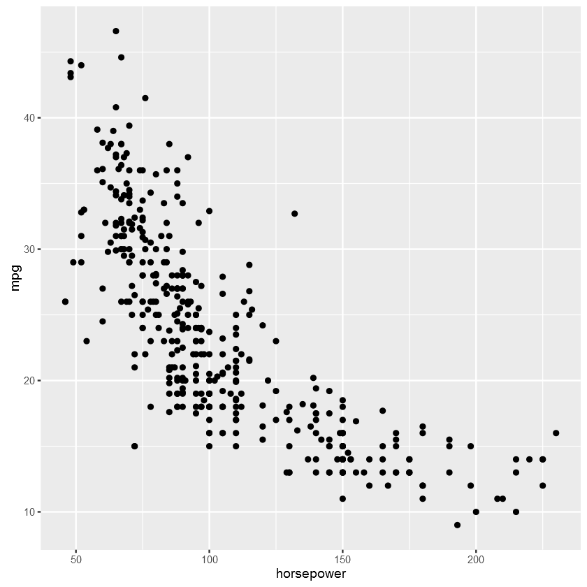

```r
ggplot(Auto, aes(x=horsepower, y=mpg))+geom_point()
```

위와 같은 자료의 분포는 곡선인 것 처럼 보인다. 이럴 때에는 변형된 형태의 예측 변수를 모형에 추가하는 것이 하나의 방법이다. 책의 3.36의 식과 같이 horsepower의 제곱 항을 모형에 넣어주면 조금 더 예측을 잘 하게 된다.

그러나 3.36은 여전히 "선형 모형" 이다. 단순히 horsepower 예측 변수와 이를 제곱한 예측 변수가 각각 들어있는 다중 회귀 모형에 다름 아니다.

```r
p <- ggplot(Auto, aes(x=horsepower, y=mpg))+geom_point()
```

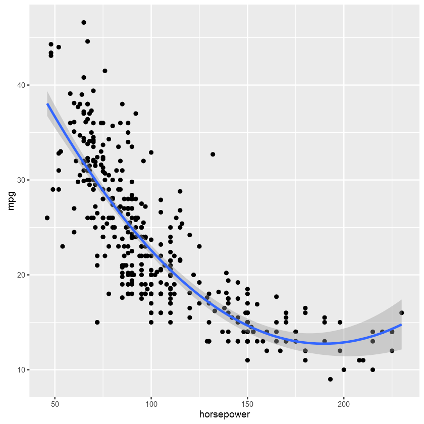

```r
p + stat_smooth(method="lm", formula = y~x+I(x^2), size = 1)
```

```r
summary(lm(mpg~horsepower + I(horsepower^2), Auto))
```

```
Call:
lm(formula = mpg ~ horsepower + I(horsepower^2), data = Auto)

Residuals:
     Min       1Q   Median       3Q      Max
-14.7135  -2.5943  -0.0859   2.2868  15.8961

Coefficients:
                  Estimate Std. Error t value Pr(>|t|)
(Intercept)     56.9000997  1.8004268   31.60   <2e-16 ***
horsepower      -0.4661896  0.0311246  -14.98   <2e-16 ***
I(horsepower^2)  0.0012305  0.0001221   10.08   <2e-16 ***
---
Signif. codes:  0 '***' 0.001 '**' 0.01 '*' 0.05 '.' 0.1 ' ' 1

Residual standard error: 4.374 on 389 degrees of freedom
Multiple R-squared:  0.6876,	Adjusted R-squared:  0.686
F-statistic:   428 on 2 and 389 DF,  p-value: < 2.2e-16
```

## 3.3.3 Potential Problems

#### 1. Non-linearity of the Data

위에서 본 것과 같이 예측 변수와 응답 변수의 관계가 비선형일 때 선형 모델을 가정하여 피팅하는 것은 무쓸모한 일. 비선형성을 가지고 있는 지 확인하는 방법은 잔차도(residual plot)의 분포를 살펴보는 것이다.

만일 선형적 모델이 자료의 분포를 잘 예측하고 있다면 잔차는 어떤 경향성을 보이지 않을 것이다. 그러나 무엇인가 문제가 있을 경우, 잔차의 분포는 어떠한 경향성을 나타낼 수 있다.

다중 회귀 모형의 경우, 예측 변수가 많기 때문에 residual vs. predicted values의 잔차도가 그려지게 된다.

만약 잔차가 비선형적 관계를 암시한다면, 예측 변수들을 비선형 형태로 변환을 하는 것이 한 가지 방법이다.

#### 2. Correlated Error Terms

선형 회귀의 가정 중 하나는 에러들이 서로 관련되지 않았다는 것이다. 다시 말해서, 이전의 에러값은 그 다음 에러 값의 추정에 아무런 정보를 주지 않는 다는 것이다.

추정된 회귀 계수들이나 모형의 예측 값들의 표준 오차(standard error)는 위의 가정에 기초하고 있다. 이 가정이 위반되면 회귀 계수들이나 예측 값들의 예측력이 하락한다는 것을 알 수 있다.

만약 에러들 간에 상관관계가 존재한다면, 추정된 표준 오차들은 실제 표준 오차들을 더 낮게 예측할 것이다. 그러면 신뢰구간 및 예측 구간들이 실제보다 더 좁아지게 된다.

출처: http://web.stanford.edu/class/stats191/notebooks/Correlated%20errors.html

```r
ntrial = 1000

sample.mean = numeric(ntrial)
sample.var = numeric(ntrial)

for (i in 1:ntrial) {
  cur.sample = arima.sim(list(ar=0.9), 100) + 1.0
  sample.mean[i] = mean(cur.sample)
  sample.var[i] = var(cur.sample)
}

data.frame(mean=mean(sample.mean), sd=sqrt(mean(sample.var)))

xval = seq(-5,5,0.05)
Y = c(density(sample.mean)$y, dnorm(xval, mean=mean(sample.mean),
                  sd=sqrt(mean(sample.var) / 100)))
X = c(density(sample.mean)$x, xval)
```

|  | mean | sd |
| --- | --- | --- |
| 1 | 1.017556 | 2.099987 |

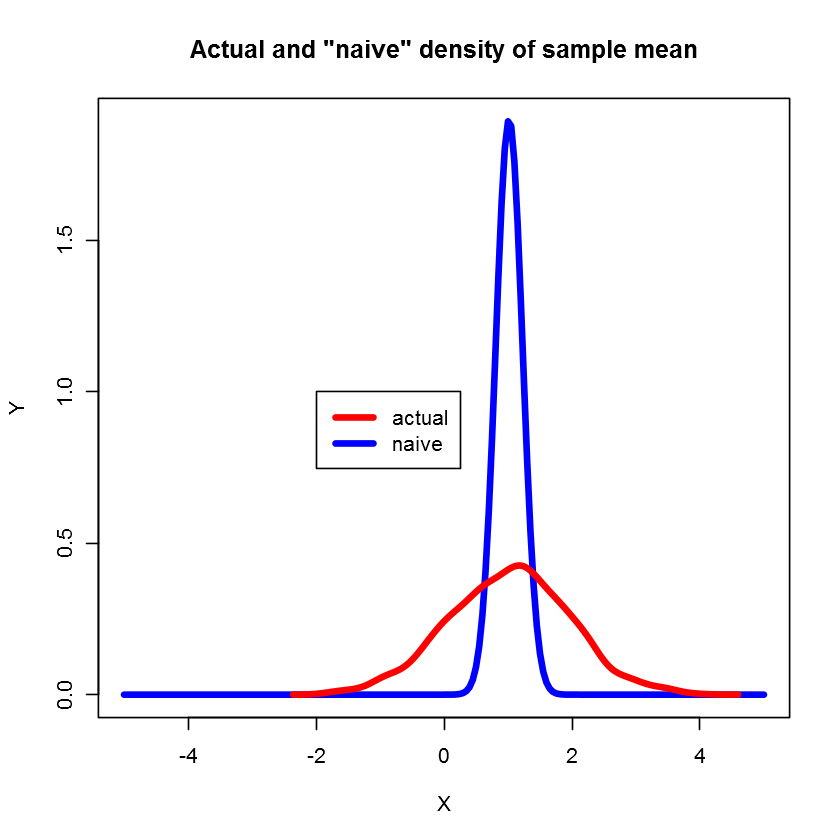

```r
plot(X, Y, type='n', main='Actual and "naive" density of sample mean')
lines(xval, dnorm(xval, mean=mean(sample.mean),
                  sd=sqrt(mean(sample.var) / 100)), lwd=4, col='blue')
lines(density(sample.mean), lwd=4, col='red')
legend(-2,1, c('actual', 'naive'), col=c('red', 'blue'), lwd=rep(4,3))
```

에러들의 상관관계는 왜 일어날까? Time Series data의 경우, 비슷한 시간 대에 관찰 된 자료들은 이 자료들의 에러들이 양의 상관관계를 가질 수 있다.

이것이 사실인지 확인해 보는 방법은, 시간에 따른 잔차를 살펴보는 것이다. 상관관계가 없다면 잔차도에서는 어떤 경향성도 나타나지 않을 것이다. 그러나 양의 상관관계가 있다면, 잔차의 tracking 이 관찰될 것이다. (Figure 3.10 참조)

에러들의 상관관계는 sampling과도 관계가 있다.

예) 개인의 신장이 개인의 체중으로부터 예측될 수 있다는 가설을 실험: 같은 가족 내 구성원들, 혹은 비슷한 식단을 유지하거나 유사한 환경 변수들에 노출된 사람들을 대상으로 실험할 경우, 개인 간에 상관관계가 존재할 수 있다.

좋은 실험 설계는 이렇게 에러의 상관관계를 최소화 하는 데 필수적이다.

#### 3. Non-constant Variance of Error Terms (heteroscedasticity, 이분산성)

선형 회귀의 또 다른 가정 중 하나는 에러들의 분산이 일정하다는 것이다. 그러나 종종 분산이 일정하지 않은 경우들이 나타난다. 이것을 알아보는 방법은 잔차도(residual plot) 에서 깔때기 모양(funnel shape)의 경향성이 관찰되는 것을 통해 확인할 수 있다.

이 경우의 해결 방법은, 응답 변수들을 concave function인 로그를 씌우거나 제곱근을 취해주면 된다. 로그나 제곱근의 특징은 큰 수일수록 줄어드는 폭이 더 크다는 것이다. 이를 통해 예측 변수의 값이 작을 때의 응답 변수의 에러는 작게 줄어들고, 예측 변수의 값이 클 때는 응답 변수의 에러가 크게 줄어들어 등분산성(homescedasticity)을 가지게끔 할 수 있다.

또한 우리는 각 응답 변수의 분산을 알고 있을 때가 있다. 예를 들어 i 번째 응답 변수는 $n_i$ 개의 응답 변수들의 평균값일 수 있다. 이런 경우에, $n_i$ 개의 응답 변수들이 모두 독립이고 분산이 $\sigma^2$ 라면, i 번째 응답 변수의 분산은 $\sigma^2/n_i$ 이다.

이런 경우의 줄어드는 분산에 대한 해결책은, weighted least squares 라는 방식이다. 분산의 역수에 비례한 가중치들을 곱해주는 것이다. 그러면 $n_i$ 개의 응답 변수들의 분산들에는 각각 1을 곱해주고, i 번째 응답 변수의 분산에는 $n_i$을 곱해주어 등분산성을 유지할 수 있게 된다.

#### 4. Outliers

Outlier 란 모형에 의해 예측된 값들로 부터 $y_i$ 값이 멀리 떨어져 있는 자료를 말한다.

책의 Figure 3.12 의 가장 왼쪽 그림을 보면 outlier가 제거되어도 least squares fit에 큰 영향을 주지 않는다.

#### It is typical for an outlier that does not have an unusual predictor value to have little effect on the least squares fit.

그러나 다른 문제들이 생겨날 수 있음.

예를 들어, outlier가 포함 되었을 때 RSE가 1.09 인데, 빠졌을 때 0.77 밖에 되지 않는다면 어떻게 될까? RSE는 분산의 추정치로 사용하는 통계치이기 때문에, 이는 회귀 계수의 신뢰구간과 p-value 에 영향을 끼치게 된다.

Outlier를 확인하는 한 가지 방법은 잔차도를 활용하는 것이다. 3.12의 가운데 그림을 보면, Outlier가 확연히 보인다. 그러나 얼마나 다른 값들과 차이가 나야 Outlier로 볼 것인지에 대한 문제가 있다.

이 문제를 해결하는 방법은, studentized residuals의 분포를 보는 것이다. studentized residual은 각 잔차를 추정된 표준 오차로 나눈 값이다. studentized residual의 절대값이 3보다 큰 경우에는 outlier라고 볼 수 있다.

자료를 얻는 과정에서 실수로 outlier가 생겼다면, 단순히 그 자료를 제외하고 분석을 하면 된다. 그러나 그렇지 않은 경우, 모델 자체의 설명력에 문제가 있을 수도 있기 때문에 제외 하는 것에 주의해야 한다(예. missing predictor)

#### 5. High Leverage Points

Outliers = 예측에 사용된 $x_i$ 에 대하여 관찰될 수 있는 $y_i$의 범주를 벗어나서 관찰되는 값

High Leverage Points = 비정상적인 $x_i$ 값

Figure 3.13의 왼쪽 그림의 41번 자료는 high leverage를 가진 점이다. 왜냐면 이 자료의 x 값이 다른 자료들의 x 값과 비교해서 크기 때문이다. 또한 41번 자료를 포함하지 않았을 경우의 least squares fit(붉은색 실선) 과 포함한 경우의 least squares fit(파란색 점선)이 다르다. 쉽게 말해 41번 자료가 전체 least squares fit을 자기 방향으로 끌어당기는(leveraging) 것이다.

소수의 leverage points 들에 의해 least squares fit 이 크게 영향을 받는다면, 그 결과는 전체 자료를 잘 나타낸다고 말할 수 없음. 그렇기 때문에 leverage points 들을 판별하는 것이 중요함.

예측 변수의 값이 정상적인 관측 범위를 벗어나는 정도로 큰 관측치를 찾으면 됨.

그러나 다중 회귀의 경우, 정상적인 관측 범위를 벗어나지 않고서도 leverage point가 되는 경우가 존재함. 예를 들어 Figure 3.13의 가운데 그림을 보면, 예측 변수가 $X_1$, $X_2$ 두 개 인데, 붉은 색 원으로 표시된 leverage point는 $X_1$의 수준에서도 비정상적 관측치가 아니고, $X_2$의 수준에서도 비정상적 관측치가 아니다.

이런 경우에 만약 $X_1$의 수준이나 $X_2$의 수준만 따로 보았다면 leverage point가 없다고 결론 내릴 수도 있음. 예측 변수가 세 개 이상일 경우에는 plotting 할 방법도 마땅히 없기 때문에 문제가 더 어려워짐.

그래서 관측치의 leverage를 정량화 하기 위해서 leverage statistic을 계산한다. 식 3.37 참조. leverage statistic $h_i$는 항상 $1/n$ 과 $1$ 사이의 값을 가진다. 평균 leverage는 항상 $(p+1)/n$ 이다. 그러므로 만일 어떤 값이 이 평균 leverage 값을 크게 상회한다면 해당 자료를 의심해 볼 수 있다.

Outlier & High leverage point: 특별히 주의해야 함!

#### 6. Collinearity (공선성)

두 개 이상의 예측 변수들 간에 높은 상관 관계가 있을 때에 collinearity가 존재한다고 한다.

Figure 3.14를 보면 왼쪽의 Limit과 Age는 서로 상관관계가 없지만, Limit과 Rating은 높은 상관관계가 존재한다. 이 경우 두 예측 변수가 collinear 라고 한다.

이는 회귀 분석에 있어 문제가 되는 데, collinear 한 예측 변수들이 개별적으로 응답 변수의 예측에 갖는 영향력을 판단하기가 어렵기 때문이다.

Figure 3.15 를 보면, 왼쪽의 등고선은 같은 수준의 RSS를 이루는 Limit 변수의 회귀 계수와 Age 변수의 회귀 계수의 추정치들의 관계를 나타낸 그림이다. 여기서 Limit 변수의 범위는 0.15 ~ 0.20 이다.

오른쪽의 등고선을 보면, limit과 rating의 회귀 계수 추정치들의 관계를 나타내었다. 두 변수는 highly collinear 하다. 같은 값의 RSS를 이루는 limit과 Age의 회귀 계수들의 범위가 훨씬 넓다.

이것은 자료가 조금만 변해도 회귀 계수가 큰 폭으로 변할 수 있다는 것을 이야기한다 (불확실성의 증가).

한 가지 흥미로운 점은, Limit과 Rating의 경우, 개별 변수의 회귀 계수는 불확실성이 더 커졌지만, 거의 확실하게 등고선을 따라 움직인다. 예를 들어 (-0.1, 1)가 각각의 변수 입장에서는 가능한 값이지만, 이 순서쌍이 두 변수들의 참 회귀 계수 값들이라고 예측하지는 않을 것이다.

회귀 계수 추정치의 정확도를 낮춘다는 것은, 표준 오차를 키운다는 것과 같다. 그러면 t 통계량의 값이 줄어들고(식 3.14 참조), 특정 회귀 계수가 0이라는, 다시 말해 특정 예측 변수가 응답 변수의 예측에 아무런 영향을 끼치지 못한다는 영가설을 기각할 수 없게 될 수도 있다.

```r
summary(lm(Balance~Age+Limit, credit))
```

```
Call:
lm(formula = Balance ~ Age + Limit, data = credit)

Residuals:
    Min      1Q  Median      3Q     Max
-696.84 -150.78  -13.01  126.68  755.56

Coefficients:
              Estimate Std. Error t value Pr(>|t|)
(Intercept) -1.734e+02  4.383e+01  -3.957 9.01e-05 ***
Age         -2.291e+00  6.725e-01  -3.407 0.000723 ***
Limit        1.734e-01  5.026e-03  34.496  < 2e-16 ***
---
Signif. codes:  0 '***' 0.001 '**' 0.01 '*' 0.05 '.' 0.1 ' ' 1

Residual standard error: 230.5 on 397 degrees of freedom
Multiple R-squared:  0.7498,	Adjusted R-squared:  0.7486
F-statistic:   595 on 2 and 397 DF,  p-value: < 2.2e-16
```

```r
summary(lm(Balance~Rating+Limit, credit))
```

```
Call:
lm(formula = Balance ~ Rating + Limit, data = credit)

Residuals:
   Min     1Q Median     3Q    Max
-707.8 -135.9   -9.5  124.0  817.6

Coefficients:
              Estimate Std. Error t value Pr(>|t|)
(Intercept) -377.53680   45.25418  -8.343 1.21e-15 ***
Rating         2.20167    0.95229   2.312   0.0213 *
Limit          0.02451    0.06383   0.384   0.7012
---
Signif. codes:  0 '***' 0.001 '**' 0.01 '*' 0.05 '.' 0.1 ' ' 1

Residual standard error: 232.3 on 397 degrees of freedom
Multiple R-squared:  0.7459,	Adjusted R-squared:  0.7447
F-statistic: 582.8 on 2 and 397 DF,  p-value: < 2.2e-16
```

위의 두 모형을 비교해 보자. Balance를 Age와 Limit으로 추정한 모형(AL)은 각 회귀 계수가 모두 통계적으로 유의하다. 반면 Rating과 Limit으로 추정한 모형(RL)은 Limit의 회귀 계수가 p-value의 증가로 인해 더 이상 통계적으로 유의미하지 않다 (0.0001 -> 0.7012). 또한 Limit의 회귀 계수의 표준 오차가 공선성으로 인해 12배가 증가하였다 (0.005 -> 0.064).

#### Limit 변수의 영향력이 공선성으로 인해 가려진 것!

공선성을 발견하는 방법은 예측 변수들의 상관행렬(correlation matrix)을 보는 것이다. 특정 두 변수들 간의 상관관계 절대값이 크면, 공선성 문제가 존재한다고 생각할 수 있다.

그러나 모든 공선성 문제가 이런 식으로 발견되지는 않는다. 세 개 이상의 변수들 간의 상관관계가 존재할 수 있기 때문이다. 이런 경우를 다중공선성(Multicollinearity)이라고 한다. 이런 경우에는 Variance inflation factor (VIF)를 계산하는 것이 한 가지 방법이다.

VIF = the ratio of the variance of $\beta_j$ when fitting the full model / the variance of $\beta_j$ if fit on its own.

가장 작은 VIF 값은 1이다 (공선성 전혀 없음).

흔히 VIF 값이 5나 10을 넘는 경우에 다중공선성 문제가 있다고 판단한다.

```r
reg1 <- lm(Balance~Age+Rating+Limit, credit)
```

```r
library(car)
```

```r
vif(reg1)
```

**Age**

1.01138468606812

**Rating**

160.668300958565

**Limit**

160.592879785974

두 가지 간단한 해결책

1) 문제가 되는 예측 변수 중 하나를 제외시킨다. -> regression fit에 큰 영향을 주지 않고서도 가능하다.

```r
reg2 <- (lm(Balance~Age+Limit, credit))
```

```r
vif(reg2)
```

**Age**

1.01028303730359

**Limit**

1.01028303730359

```r
summary(reg2)
```

```
Call:
lm(formula = Balance ~ Age + Limit, data = credit)

Residuals:
    Min      1Q  Median      3Q     Max
-696.84 -150.78  -13.01  126.68  755.56

Coefficients:
              Estimate Std. Error t value Pr(>|t|)
(Intercept) -1.734e+02  4.383e+01  -3.957 9.01e-05 ***
Age         -2.291e+00  6.725e-01  -3.407 0.000723 ***
Limit        1.734e-01  5.026e-03  34.496  < 2e-16 ***
---
Signif. codes:  0 '***' 0.001 '**' 0.01 '*' 0.05 '.' 0.1 ' ' 1

Residual standard error: 230.5 on 397 degrees of freedom
Multiple R-squared:  0.7498,	Adjusted R-squared:  0.7486
F-statistic:   595 on 2 and 397 DF,  p-value: < 2.2e-16
```

Rating을 제외하고 회귀 모형을 구성했을 경우, Age와 Limit의 VIF 가 1로서, 다중공선성 문제가 해결되고, $R^2$ 의 감소 폭이 매우 적다 (0.754 -> 0.75).

2) collinear 한 변수들을 하나의 예측 변수로 만드는 것이다. 예를 들면 limit과 rating의 평균을 낸 값들을 새로운 변수로 삼아 회귀 모형에 사용할 수 있다.

# 3.4 The Marketing Plan

## 1. Is there a relationship between advertising sales and budget?

판매량을 TV, 라디오, 신문을 통혜 예측하는 다중회귀 모형의 설정을 통해 질문에 대답할 수 있다. 식 3.20 참조.

```r
summary(lm(Sales~TV+Radio+Newspaper, advertising))
```

```
Call:
lm(formula = Sales ~ TV + Radio + Newspaper, data = advertising)

Residuals:
    Min      1Q  Median      3Q     Max
-8.8277 -0.8908  0.2418  1.1893  2.8292

Coefficients:
             Estimate Std. Error t value Pr(>|t|)
(Intercept)  2.938889   0.311908   9.422   <2e-16 ***
TV           0.045765   0.001395  32.809   <2e-16 ***
Radio        0.188530   0.008611  21.893   <2e-16 ***
Newspaper   -0.001037   0.005871  -0.177     0.86
---
Signif. codes:  0 '***' 0.001 '**' 0.01 '*' 0.05 '.' 0.1 ' ' 1

Residual standard error: 1.686 on 196 degrees of freedom
Multiple R-squared:  0.8972,	Adjusted R-squared:  0.8956
F-statistic: 570.3 on 3 and 196 DF,  p-value: < 2.2e-16
```

세 가지 광고 방법에 투자하는 비용이 모두 판매량과 관련이 없다는 영가설은 쉽게 기각할 수 있다. 위 모형의 F 통계치의 p-value를 주목하라.

## 2. How strong is the relationship?

모형의 적합성을 판단하는 척도는 두 가지: 1. RSE 값 2. $R^2$

위 모형의 RSE = 1.686, $R^2$ = 0.8972. 자료의 매우 많은 부분을 모형이 설명하고 있다고 주장할 수 있다.

## 3. Which media contribute to sales?

각 예측 변수의 t 통계치에 해당하는 p-value 들을 관찰해야 한다. TV와 라디오의 p-value는 매우 낮으나 신문의 경우 그 값이 높아 판매량에 기여하고 있다고 보기 어렵다.

## 4. How large is the effect of each medium on sales?

각각의 회귀 계수들의 신뢰 구간을 구해주면 된다.

혹시 세 변수 간에 다중공선성 문제가 있어서 신문의 회귀 계수의 p-value가 masking 된 것일까?

```r
reg3 <- lm(Sales ~ TV+Radio+Newspaper, advertising)
```

```r
vif(reg3)
```

**TV**

1.00461078493965

**Radio**

1.14495191710554

**Newspaper**

1.14518737872393

그렇지 않다.

## 5. How accurately can we predict future sales?

이 질문은 두 가지로 정리될 수 있다.

1. 개별 관측치를 얼마나 정확하게 예측하는지?
2. 응답 변수들의 평균을 얼마나 정확하게 예측하는지?

1의 경우에는 prediction interval을 이용하여 irreducivle error에 대한 예측을 담도록 한다. 2의 경우에는 신뢰구간을 구해주면 된다.

## 6. Is the relationship linear?

```r
plot(lm(Sales~TV+Radio+Newspaper, advertising))
```

[figure not shown]

잔차의 분포를 보면 어떠한 경향성이 나타난다는 것을 볼 수 있다. 선형적인 관계가 아니다. 이것은 Figure 3.5를 통해서도 확인하였다.

이렇게 linear 하지 않을 경우 각 예측 변수들의 변환된 형식(예를 들어 제곱을 한 형태)을 모형에 추가하면 더 좋은 fit을 얻을 수 있다.

## 7. Is there synergy among the advertising media?

일반적인 선형 회귀 모형은 가법적(additive)이다.

이는 예측 변수들 간의 관계가 존재하지 않기 때문에 설명하기 편하다는 장점이 있으나 잠재하는 synergy effect를 나타내지 못한다.

상호작용 효과를 나타내는 변수를 모형에 포함하고, 이 변수의 p-value가 작을 때 상호작용 효과가 있다고 할 수 있다. Figure 3.5 에서 synergy effect가 있음을 확인하였다.

```r
summary(lm(Sales~TV*Radio, advertising))
```

```
Call:
lm(formula = Sales ~ TV * Radio, data = advertising)

Residuals:
    Min      1Q  Median      3Q     Max
-6.3366 -0.4028  0.1831  0.5948  1.5246

Coefficients:
             Estimate Std. Error t value Pr(>|t|)
(Intercept) 6.750e+00  2.479e-01  27.233   <2e-16 ***
TV          1.910e-02  1.504e-03  12.699   <2e-16 ***
Radio       2.886e-02  8.905e-03   3.241   0.0014 **
TV:Radio    1.086e-03  5.242e-05  20.727   <2e-16 ***
---
Signif. codes:  0 '***' 0.001 '**' 0.01 '*' 0.05 '.' 0.1 ' ' 1

Residual standard error: 0.9435 on 196 degrees of freedom
Multiple R-squared:  0.9678,	Adjusted R-squared:  0.9673
F-statistic:  1963 on 3 and 196 DF,  p-value: < 2.2e-16
```

이렇게 상호작용 효과를 나타내는 변수를 포함하고, 그 변수의 회귀 계수의 p-value 가 유의 수준 이하인 것을 확인하여 상호작용 효과가 존재함을 관찰하였다.

# 3.5 Comparison of Linear Regression with K-Nearest Neighbors

parametric method는 몇 가지 장점이 있음

1. easy to fit : 계수 몇 개만 추정하면 끝나기 때문
2. 선형 회귀 모형의 경우, 계수들은 해석하기도 쉽고, 통계적 유의미성의 검증도 수월하다.

단점도 존재한다.

1. f(X) 의 모양에 대한 예측을 하고 들어간다 -> 실제 자료의 분포가 예측과 다르면 무쓸모

non-parametric methods 는 좀 더 유연한 접근 방식을 제공한다.

K-Nearest Neighbors regression (KNN-Regression)

2장에서 살펴본 KNN classifier와 비슷하다.

prediction point $x_0$ 가 주어지면, 우선 $x_0$와 가까운 K 개의 트레이닝 자료를 판별한다. 그러고 난 다음에는 그 자료들의 평균을 통해 f($x_0$)를 추정한다.

Figure 3.16을 보면, K = 1, K = 9 인 경우가 각각 보인다. K = 1 일때는 자료의 예측이 rough step function 으로 나오나, K = 9 일 때는 좀 더 smooth step function으로 y 값을 예측하고 있음을 알 수 있다.

최적의 K 값은 bias-variance tradeoff를 고려하여 선택한다.

K 가 작으면 flexible 하기 때문에 bias 가 적고 variance가 크다. 이것은 주어진 범위 내에서의 예측이 단 하나의 관측치를 통해서 이뤄지기 때문 (해당 관측치의 변화가 예측에 미치는 영향이 크다)

K 가 크면 less flesxible, 범위 내의 한 값이 변하더라도 다른 값들과의 평균으로 추정하기 때문에 bias는 조금 더 커지더라도 variance는 작다.

## 어떤 환경에서 parametric approach가 non-parametric 보다 더 좋은가?

선택된 parametric form이 실제 f 값과 유사할 경우

Figure 3.17 을 보면, 실제 f 가 검은색 직선이라고 할 때, K가 1이건 9이건 단순 선형 회귀 모형의 설명력과는 비교할 수가 없다.

#### bias를 줄이는 것으로는 상쇄되지 않는 variance cost를 발생시키기 때문???

Figure 3.18 을 보면 선형 회귀 모형(푸른색 점선)이 실제 함수를 가장 잘 예측하고 있음을 알 수 있다. 오른쪽 그래프를 보더라도, KNN의 MSE가 K가 작아짐에 따라 증가하는 것을 볼 수 있다.

#### 그러나,

실제로 예측 변수와 응답 변수의 관계가 선형일 때는 그리 많지 않다. 이런 경우에는 KNN이 훨씬 더 설명력이 좋기도 하다.

Figure 3.19를 보면, 왼쪽 그래프에서 관찰되는 자료의 개형이 약간 비선형임을 알 수 있다. 이 경우에는 K 가 작을 경우에는 여전히 선형 회귀 모형이 설명력이 더 좋으나(RSE 값이 더 작음) K 값이 증가함에 따라서 KNN regression model이 더 설명력이 좋음을 알 수 있다.

자료의 개형이 훨씬 더 비선형일 경우에는 K 값과 무관하게 KNN이 설명력이 더 좋은 것을 관찰할 수 있다.

비선형 정도가 증가함에 따라서, KNN 같은 경우에는 test-set MSE 에 별 차이가 없으나, 선형 회귀 모형의 경우 그 변동 폭이 크다.

실제로는 참 관계가 매우 비선형적이더라도 knn이 선형 회귀보다 더 설명력이 나쁠 수 있다. 예를 들어 예측 변수의 개수가 많아지게 되면, 차원이 커지게 된다. 이는 예측을 위해 주어진 $x_0$ 와 data point 간의 공간 내 거리가 더 늘어남을 뜻하고,

#### KNN을 사용하는 경우 더 안 좋은 예측을 내 놓는 결과를 가져오게 된다 (curse of dimensionality) ???